# GGPLOT2 - Livro R para DS

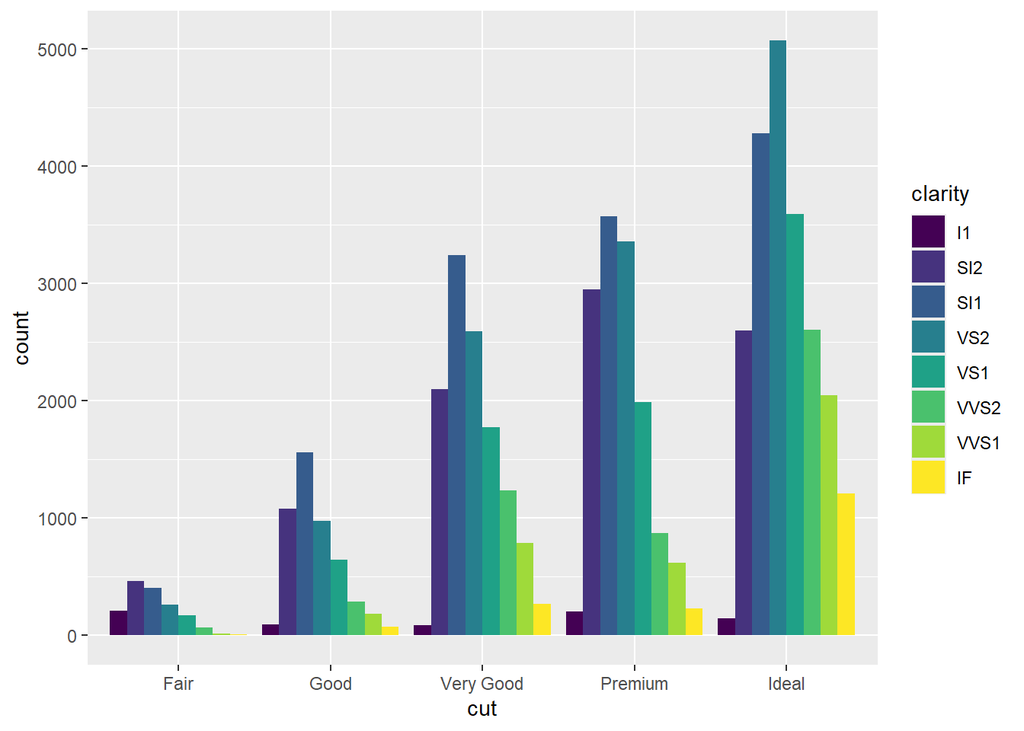

```r
ggplot(data = diamonds)+
  geom_bar(mapping = aes(x= cut, fill= clarity), position = 'dodge')
```

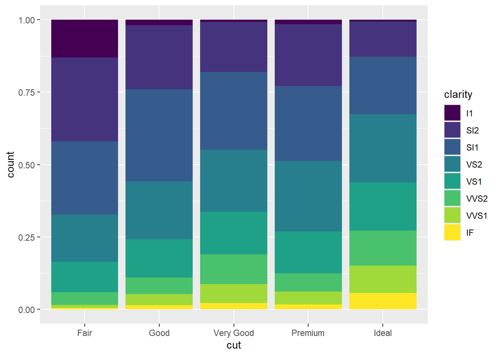

```r
ggplot(data = diamonds)+
  geom_bar(mapping = aes(x= cut, fill= clarity), position= 'fill')
```

Para alterar os sistemas de coordenadas as duas funções mais importantes são *coord_flip* que troca as posições dos eixos x e y no sistema cartesiano, que é o sistema padrão do R e a função coord_polar que altera a representação para coordenadas no sistema polar.

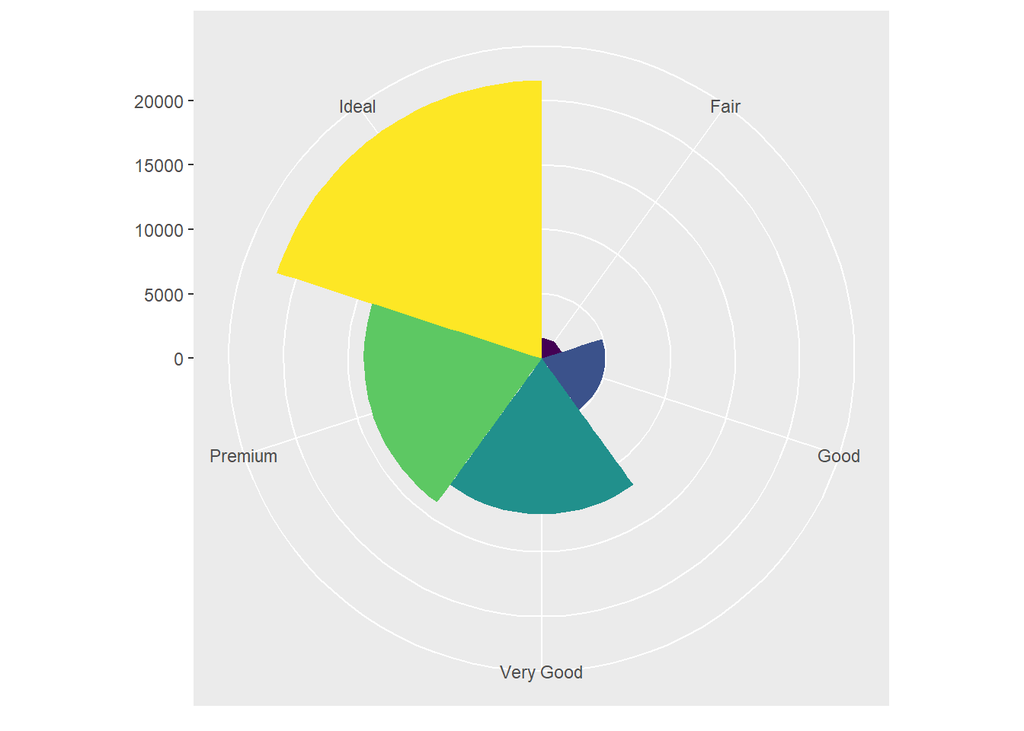

```r
ggplot(data = diamonds)+
  geom_bar(mapping = aes(x= cut, fill = cut), show.legend = FALSE, width = 1)+
  theme(aspect.ratio = 1)+  # delimita uma proporção quadrada 1:1
  labs(x=NULL, y=NULL)+    # remove os eixos
  coord_polar()
```

Com dados contínuos uma situação corriqueira é precisarmos representar vários recortes ou variáveis sobrepondo histogramas contudo, a leitura deste tipo de gráfico sobreposto não é muito fácil. Principalmente se forem sobrepostos mais do que dois ou três. Para estas situações o uso de cursas sobrepostas pode ser mais ilustrativo e de fácil leitura.

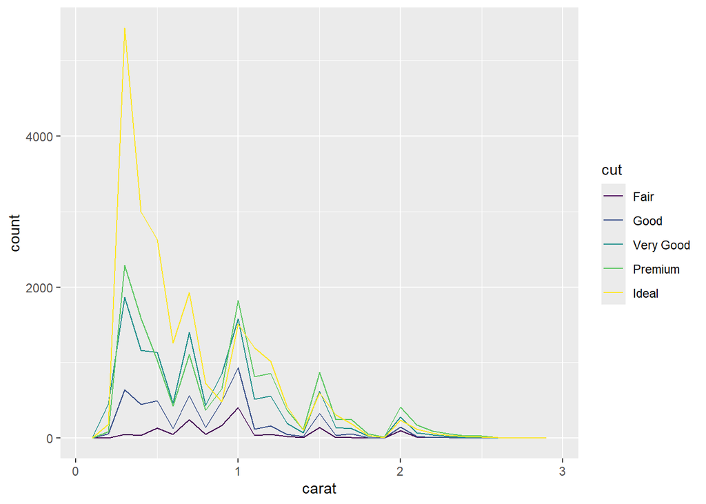

```r
diamonds |>
  filter(carat < 3) |>
  ggplot(aes(x=carat, color=cut))+
  geom_freqpoly(binwidth = 0.1)  # tamanho dos recortes
```

O tipo de gráfico acima exibe a contagem de cada valor mas para efeitos de comparação é mais adequado que façamos a exibição pela densidade que padroniza a representação para que a área de cada polígono de frequência seja um.

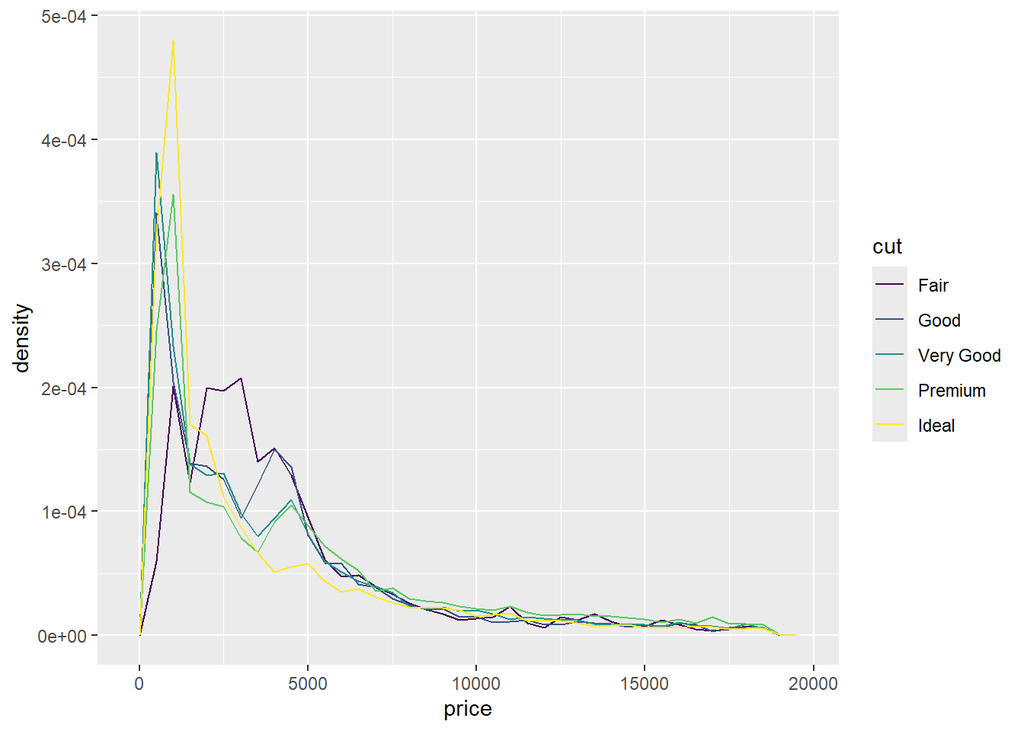

```r
diamonds |>
  ggplot(aes(x=price, y=..density..))+
  geom_freqpoly(mapping=aes(color=cut), binwidth = 500)
```

Uma outra alternativa para representar variáveis contínuas extratificadas por uma outra categórica é a utilização de boxplots. comparado com a representação acima o boxplot apresenta menos informações mas é muito mais conciso e apresenta uma síntese das principais estatísticas.

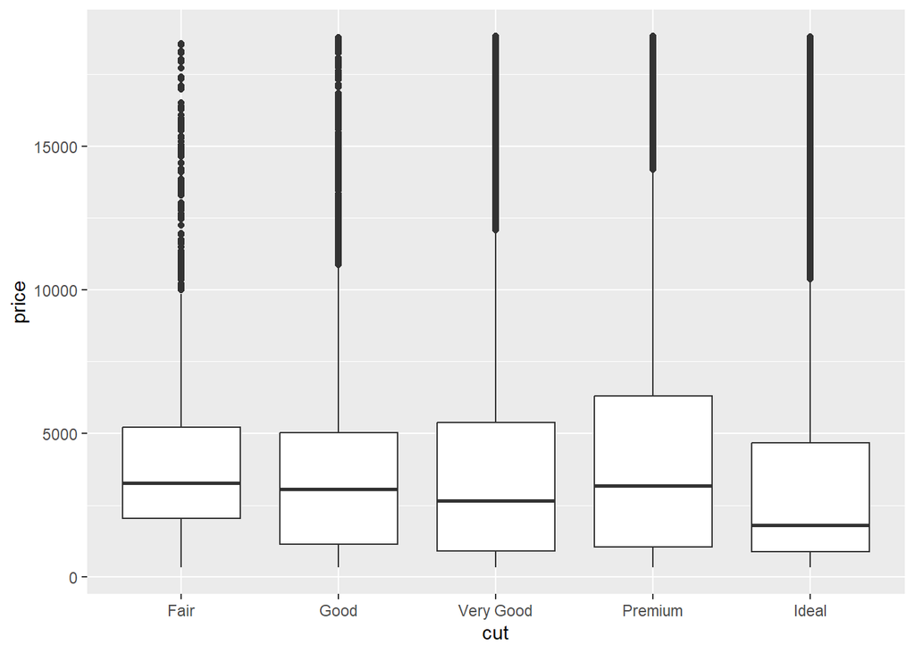

```r
ggplot(data = diamonds, mapping = aes(x= cut, y=price))+
  geom_boxplot()
```

Note que não fica evidente uma tendência na nos dados. O que pode ser melhorado com realizando uma ordenção. Se as categorias de variável categórica tiverem nomes longos a representação fica mais elegante se for feita uma rotação na representação. Isso pode ser feito acrescento simplesmente coord_flip.

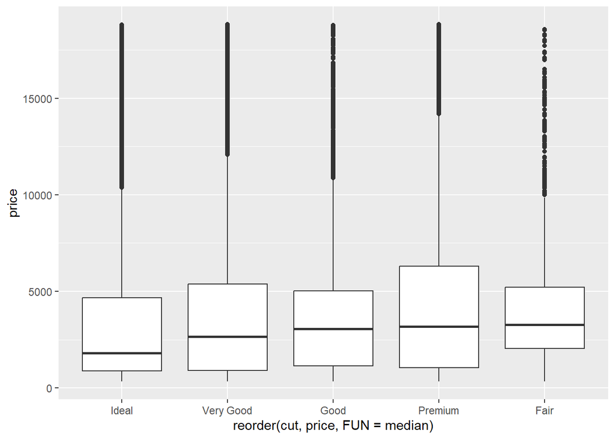

```r
ggplot(data = diamonds)+
  geom_boxplot(mapping = aes(x= reorder(cut, price, FUN= median), y=price))
```

Para representar a relação entre duas variáveis categóricas podemos também utilizar uma mapa de circulos que serão gerados pelo uso de geom_count. Note que o tamanho do círculo está relacionado ao tamanho da contagem.

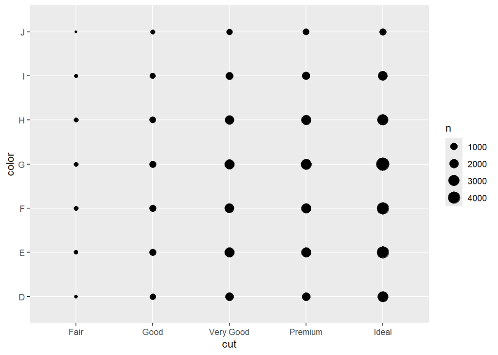

```r
ggplot(data = diamonds) +
  geom_count(mapping= aes(x=cut, y=color))
```

Uma outra alternativa para representar a relação entre duas variáveis categóricas é utilizar mapas de calor (heatmaps).

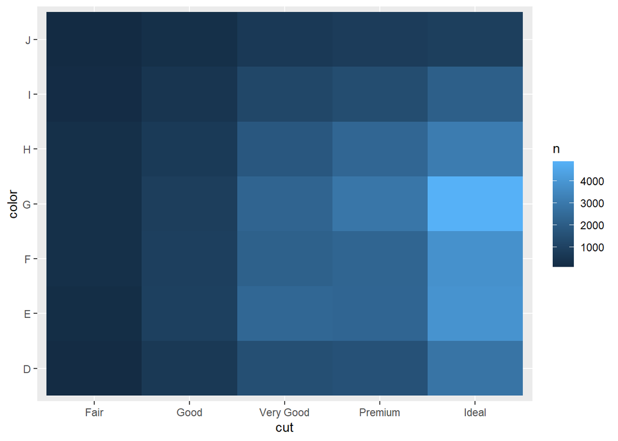

```r
diamonds |>
  count(cut, color) |>
  ggplot(mapping = aes(x=cut, y=color))+
  geom_tile(mapping = aes(fill=n))
```

Para representar duas variáveis continuas os gráficos de dispersão são bastante eficeientes e quando acontecem muitos dados sobrepostos uma alternativa viável para um bom número de casos é a utilização do parâmtreto alpha. Entretanto, uma outro alternativa que pode ser interessante é particionar uma das variáveis como se fosse categórica e representar utilizando boxplots. O parâmetro cut_width particiona a variável com o intervalo especificado.

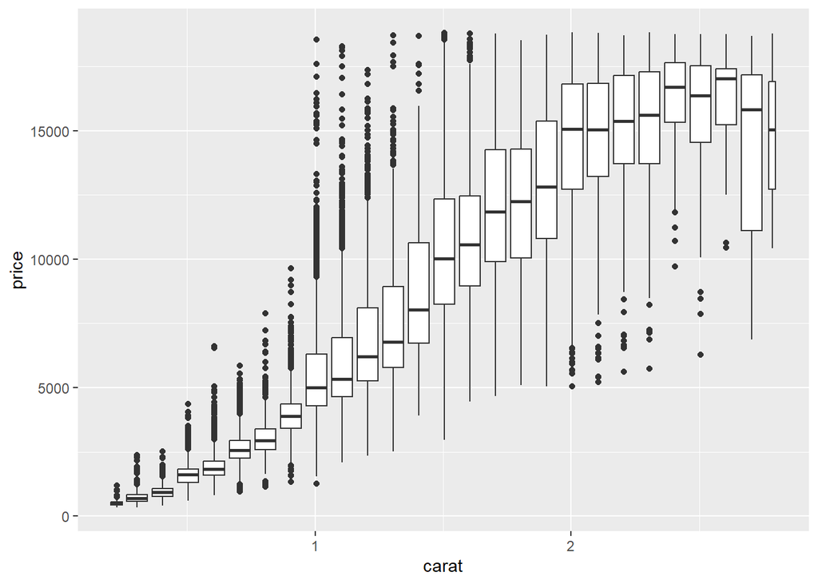

```r
diamonds |>
  filter(carat < 3) |>
  ggplot(mapping = aes(x=carat, y=price))+
  geom_boxplot(mapping = aes(group= cut_width(carat, 0.1)))
```

No gráfico acima todos os boxplots tem o mesmo tamanho e variam apenas conforem a contagem e os outliers. Mas poderíamos deixá-los mais representativos utilizando varwidth = TRUE que tornaria a largura proporcional a contagem do intervalo. Um outra maneira seria usando cut_number especificando quantos valores serão incluídos em cada intervalo especificado.

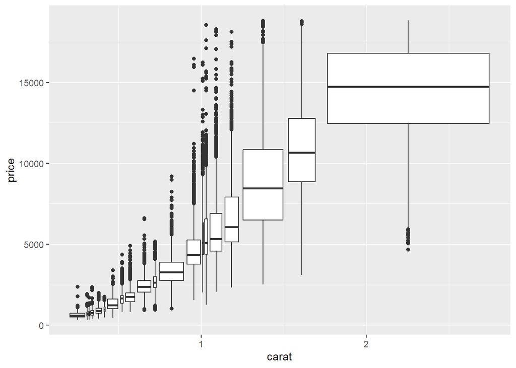

```r
diamonds |>
  filter(carat < 3) |>
  ggplot(mapping = aes(x=carat, y=price))+
  geom_boxplot(mapping = aes(group= cut_number(carat, 20)))
```

No exemplo abaixo os intervalos foram ampliados para que se tenha menos velas e também foi incluído o parâmetro para que a largura seja proporcional a frequência encontrada. Estes ajustes podem colaborar para que tendências e relações sejam mais facilmente percebidas e identificadas.

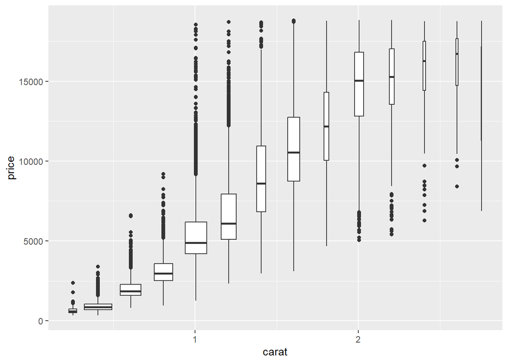

```r
diamonds |>
  filter(carat < 3) |>
  ggplot(mapping = aes(x=carat, y=price))+
  geom_boxplot(mapping = aes(group= cut_width(carat, 0.2)), varwidth = TRUE)
```

# ReadR package

Outra possibilidade muito interessante é que as vezes os dados estão separados em multiplos arquivos. Nestas situações é possível transferir todos eles para o R de uma vez usando as funções do readr. Por exemplo, se você tiver multiplos arquivos de vendas, uma para cada mês: 01-sales.csv para janeiro, 02-sales.csv para fevereiro, e 03-sales.csv para março. Com read_csv() é possivel ler todos estes dados de uma única vez e gravalos um na sequência do outro no mesmo dataframe. Lembre que os arquivos precisam estar todos na mesma pasta.

sales_files <- c(“data/01-sales.csv”, “data/02-sales.csv”, “data/03-sales.csv”)  
read_csv(sales_files, id = “file”) # o argumento id adiciona uma nova coluna chamada file

Par escrever arquivos o pachage readr dispões de write_csv(). Por exemplo: write_csv(students, “students.csv”). O primeiro valor indica o dado constante no ambiente do R que será gravado e o segundo valor indica o nome e a extensão com os dados serão gravados.

Um aspecto importanet é que write_csv não permite que sejam salvos no arquivo detalhes de alterações e ajustes nos dados feitos no ambiente do R, ou seja, são salvos apenas os valores das variáveis. Caso se deseje salvar resultados parciais com todas as informações de ajustes feitos no ambiente do R para continuar o trabalho posteriormente o uso do formato rds que é nativo do R é mais interessante. Neste caso usamos write_rds() e read_rds() respectivamente para escrever e depois para ler os arquivo.

> Por exemplo:  
> write_rds(students, “students.rds”)  
> read_rds(“students.rds”)

### Por que usar readr e não o R base?

- as funções de readr são muito mais rápidas do que as funções de leitura do R base.
- Produzem tibbles e não convertem vetores em fatores.
- São mais reprodutiveis por não herdarem comportamentos do sistema operacional

### Lendo dados diretamente do clipboard para o R

Pode-se usar a função readClipboard(), que no exemplo abaixo colaria os dados diretamente na variável x.

x <- readClipboard()

Se os dados do clipboard forem tabulares (uma tabela, por exemplo), você também pode utilizar a função read.table() que também permite especificar outras parâmetros. Por exemplo:

x <- read.table(file = “clipboard”, sep = “, header = FALSE)

Para colar dados copiados de tabelas da internet diretamente pode ser um pouco trabalhoso pois, dependendo do site serão necessárias várias configurações e será necessário verificar a documentação de read.table.

### Lendo outros formatos de arquivo.

- O package **haven** permite a leitura de arquivos do SPSS, SAS e Stata.
- O package **readxl** é capaz de ler arquivos nos formatos .xls e .xlsx do MS Excel.

# Arrumando os dados com tidyr

Como diria Hadkey Wickham dados organizados são todos iguais e dados desorganizados são todos bagunçados cada um a sua maneira. Neste cenário existem três regras que caracterizam um conjunto de dados como tidy. 1. Cada variável deve ter sua própria coluna. 2. Cada observação deve ter sua própria linha. 3. Cada valor deve ter sua própria célula. Um problema comum em dataframes é que o nome de certas colunas são na verdade dados de alguma variável. Podemos usar *gather* para alterar a disposição dos dados. Os parâmetros col1 e col2 indicam as duas colunas que representam valores e não variáveis. O nome da coluna que irá unir col1 e col2 será indicada pela parâmetro key e os valores serão armazenados na coluna values. Por exemplo: gather( col1, col2, key = ‘nome_nova_coluna’, values = ‘Nome_coluna_valores’)

Por outo lado *spread* separa os dados de uma variável. Por exemplo: spread (dataframe, key = ‘coluna_dados_separados’, values = ‘coluna_com_valores’).

Como deve ter sido possível perceber a função gather torna as tabelas extensas mais estreitas e longas, enquanto que a função spread torna as tabelas extensas mais curtas e largas.

Outra função qeu faz parte do packag tidyr é a função separate que permite separar os dados de uma variável que esta expressa na forma de uma razão. Por exemplo: separate(coluna_deseja_separar, into = c(‘nome_col1’, ‘nome_col2’), sep = ‘/’)

Se aquilo que se deseja for unir dados em uma coluna se pode utilizar a função *unite*. A qual faz exatamente o contrário de separate. Por exemplo: unite (nome_nova_coluna, nome_col1_unir nome_col2_unir, sep = ““)